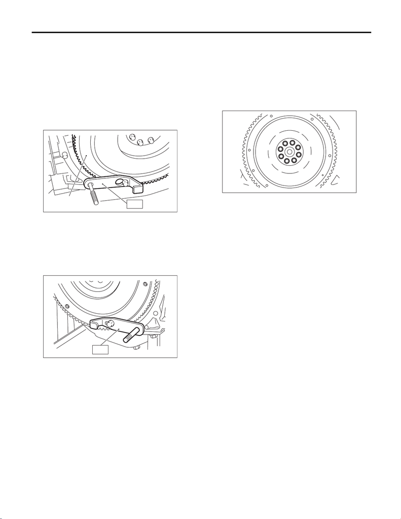

CL-15

Flywheel

CLUTCH SYSTEM

3. Flywheel

A: REMOVAL

1) Remove the transmission assembly. <Ref. to

6MT(TY75)-25, REMOVAL, Manual Transmission

Assembly.> <Ref. to 6MT(TY85)-31, REMOVAL,

Manual Transmission Assembly.>

2) Remove the clutch cover and clutch disc. <Ref.

to CL-12, REMOVAL, Clutch Disc and Cover.>

3) Using the ST, remove the flywheel.

ST 498497100 CRANKSHAFT STOPPER

B: INSTALLATION

1. STI MODEL

1) Install the flywheel and ST.

ST 498497100 CRANKSHAFT STOPPER

2) Tighten the flywheel mounting bolts to the spec-

ified torque.

NOTE:

Tighten the flywheel attachment bolts gradually.

Each bolt should be tightened to the specified

torque in crisscross order.

Tightening torque:

75 N·m (7.6 kgf-m, 55.3 ft-lb)

3) Install the clutch disc and cover. <Ref. to CL-12,

INSTALLATION, Clutch Disc and Cover.>

4) Install the transmission assembly. <Ref. to

6MT(TY75)-30, INSTALLATION, Manual Trans-

mission Assembly.> <Ref. to 6MT(TY85)-33, IN-

STALLATION, Manual Transmission Assembly.>

(A) Flywheel

CL-00019

ST

(A)

CL-00801

ST

CL-00021

(1)

(2)

(3)

(4)

(5)

(6)

(7)

(8)

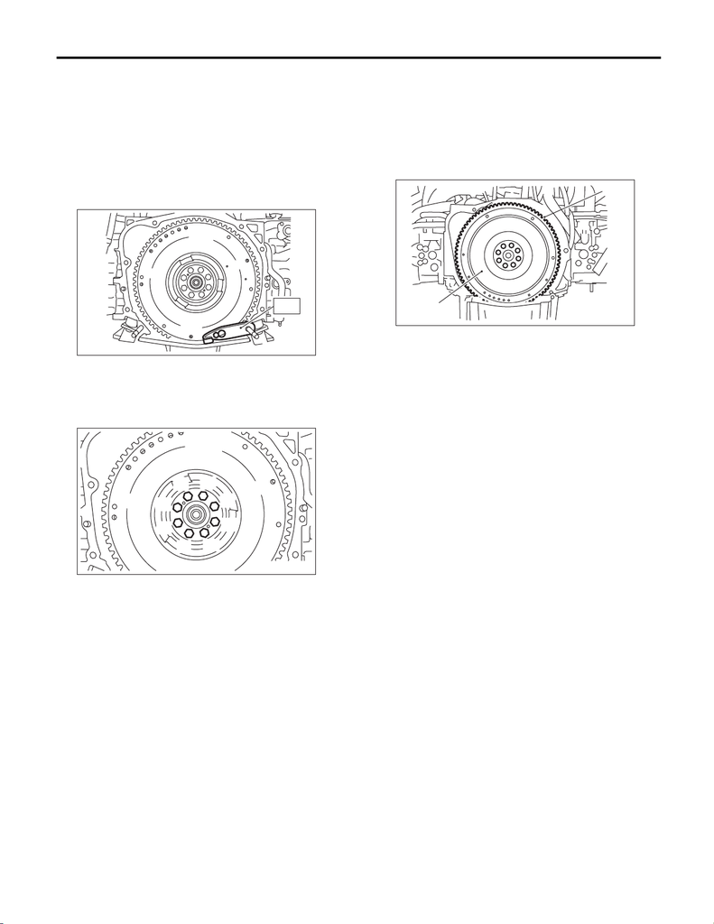

CL-16

Flywheel

CLUTCH SYSTEM

2. EXCEPT FOR STI MODEL

1) Temporarily install the crankshaft position sen-

sor plate and flywheel.

NOTE:

Align the knock pin hole of the crankshaft position

sensor plate to the knock pin of the crankshaft to

secure the knock pin.

2) Attach the ST.

ST 498497100 CRANKSHAFT STOPPER

3) Tighten the flywheel mounting bolts in two stages.

(1) Tighten the flywheel attachment bolts.

Tightening torque:

30 N·m (3.1 kgf-m, 22.1 ft-lb)

(2) While checking the tightening angle with the

angle gauge, further tighten the flywheel mount-

ing bolts.

Tightening angle:

30° — 35°

4) Install the clutch disc and cover. <Ref. to CL-12,

INSTALLATION, Clutch Disc and Cover.>

5) Install the transmission assembly. <Ref. to

6MT(TY75)-30, INSTALLATION, Manual Trans-

mission Assembly.>

C: INSPECTION

CAUTION:

Because the center bearing is grease-sealed

and is a non-lubrication type, do not wash with

gasoline or solvents.

1) If there is damage or defectiveness in the facing

sliding surface or ring gear, replace the flywheel.

2) Smoothness of rotation

Rotate the ball bearing while applying pressure in

the thrust direction.

3) If noise or excessive play is noted, replace the

flywheel.

ST

CL-00820

(1)

(5)

(2)

(3)

(4)

(6)

(7)

(8)

CL-00821

(A) Flywheel

(B) Ring gear

CL-00022

(B)

(A)